# Importing Data in Python (Part 1)

- William Surles
- 2019-10-19
- Datacamp course notes
- https://www.datacamp.com/courses/importing-data-in-python-part-1

## Whats Covered

- Introduction and flat files
  - Import text files
  - The importance of flat files in data science
  - Importing flat files using NumPy
  - Importing flat files using pandas
- Importing data from other files
  - Importing Excel files
  - Importing SAS/Stata files using pandas
  - Imporitng HDF5 files
  - Importing MATLAB files
- Working with relational databases in Python
  - Creating a database engine
  - Querying relationsl databases in Python
  - Querying relational databases directly with pandas
  - Advanced Qyerying: exploiting table relationships

## Additional Resources

- [PEP8 Style guide for python](https://www.python.org/dev/peps/pep-0008/)
- [PEP20 The Zen of Python](https://www.python.org/dev/peps/pep-0008/)

## Packages and data

```python
import numpy as np
import urllib.request
import matplotlib.pyplot as plt
```

# Introduction and flat files

## Welcome to the course!

#### Reading a text file

```python
filename = 'huck_finn.txt'
# 'r' is to read, we would use 'w' to write
file = open(filename, mode='r')
text = file.read()
file.close()
print(text)
```

```
CHAPTER I.

YOU don't know about me without you have read a book by the name of The Adventures of Tom Sawyer; but that ain't no matter. That book was made by Mr. Mark Twain, and he told the truth, mainly. There was things which he stretched, but mainly he told the truth. That is nothing. I never seen anybody bu…

Now the way that the book winds up is this: Tom and me found the money that the robbers hid in the cave, and it made us rich. We got six thousand dollars apiece--all gold. It was an awful sight of money when it was piled up. Well, Judge Thatcher he took it and put it out at interest, and it fetched …
```

#### Context manager with

- Once out of this context the file will no longer be open
- `with` is called a 'context manager'
- this is the best practice

```python
with open('huck_finn.txt','r') as file:
    print(file.read())
```

```
CHAPTER I.

YOU don't know about me without you have read a book by the name of The Adventures of Tom Sawyer; but that ain't no matter. That book was made by Mr. Mark Twain, and he told the truth, mainly. There was things which he stretched, but mainly he told the truth. That is nothing. I never seen anybody bu…

Now the way that the book winds up is this: Tom and me found the money that the robbers hid in the cave, and it made us rich. We got six thousand dollars apiece--all gold. It was an awful sight of money when it was piled up. Well, Judge Thatcher he took it and put it out at interest, and it fetched …
```

### Exploring your working directory

```python
! ls
```

```
custom.css                            importing_data_in_python_part_1.html
huck_finn.txt                         importing_data_in_python_part_1.ipynb
```

### Importing entire text files

```python
# Open a file: file
file = open('huck_finn.txt', mode = 'r')

# Print it
print(file.read())

# Check whether file is closed
print(file.closed)

# Close file
file.close()

# Check whether file is closed
print(file.closed)
```

```
CHAPTER I.

YOU don't know about me without you have read a book by the name of The Adventures of Tom Sawyer; but that ain't no matter. That book was made by Mr. Mark Twain, and he told the truth, mainly. There was things which he stretched, but mainly he told the truth. That is nothing. I never seen anybody bu…

Now the way that the book winds up is this: Tom and me found the money that the robbers hid in the cave, and it made us rich. We got six thousand dollars apiece--all gold. It was an awful sight of money when it was piled up. Well, Judge Thatcher he took it and put it out at interest, and it fetched …

False
True
```

### Importing text files line by line

```python
# Read & print the first 3 lines
with open('huck_finn.txt') as file:
    print(file.readline())
    print(file.readline())
    print(file.readline())
```

```
CHAPTER I.



YOU don't know about me without you have read a book by the name of The Adventures of Tom Sawyer; but that ain't no matter. That book was made by Mr. Mark Twain, and he told the truth, mainly. There was things which he stretched, but mainly he told the truth. That is nothing. I never seen anybody bu…
```

## The importance of flat files in data science

### Pop quiz: what exactly are flat files?

- Flat files consist of rows and each row is called a record.
- A record in a flat file is composed of fields or attributes, each of which contains at most one item of information.
- Flat files are pervasive in data science.

### Why we like flat files and the Zen of Python

- Guido van Rossum wrote python and PEP8 is his style guide
- The zen of python suggest that 'flat is better than nested'

```python
import this
```

```
The Zen of Python, by Tim Peters

Beautiful is better than ugly.
Explicit is better than implicit.
Simple is better than complex.
Complex is better than complicated.
Flat is better than nested.
Sparse is better than dense.
Readability counts.
Special cases aren't special enough to break the rules.
Although practicality beats purity.
Errors should never pass silently.
Unless explicitly silenced.
In the face of ambiguity, refuse the temptation to guess.
There should be one-- and preferably only one --obvious way to do it.
Although that way may not be obvious at first unless you're Dutch.
Now is better than never.
Although never is often better than *right* now.
If the implementation is hard to explain, it's a bad idea.
If the implementation is easy to explain, it may be a good idea.
Namespaces are one honking great idea -- let's do more of those!
```

## Importing flat files using NumPy

#### Why NumPy?

- NumPy arrys are standard for storing numerical data
- These are used in other packages like scikit-learn
- Its easy to import data into arrays
  - `load(txt)`
  - `genfromtxt()`

#### Importing flat files using Numpy

Okay, I had to do some searching around to figure out how to load a file from the interwebs. This is one thing that is a bit messy in how it has changed from python 2 to 3 and the answers out there vary based on this. But, in the end, this works. Nice!

```python
# import urllib.request

file_url = urllib.request.urlopen('https://assets.datacamp.com/production/course_1607/datasets/mnist_kaggle_some_rows.csv')

data = np.loadtxt(file_url, delimiter = ',')

data
```

```
array([[ 1.,  0.,  0., ...,  0.,  0.,  0.],
       [ 0.,  0.,  0., ...,  0.,  0.,  0.],
       [ 1.,  0.,  0., ...,  0.,  0.,  0.],
       ...,
       [ 2.,  0.,  0., ...,  0.,  0.,  0.],
       [ 0.,  0.,  0., ...,  0.,  0.,  0.],
       [ 5.,  0.,  0., ...,  0.,  0.,  0.]])
```

Here is how you get them when on the computer...

```python
filename = 'mnist_kaggle_some_rows.csv'

data = np.loadtxt(filename, delimiter = ',')

data
```

```
array([[ 1.,  0.,  0., ...,  0.,  0.,  0.],
       [ 0.,  0.,  0., ...,  0.,  0.,  0.],
       [ 1.,  0.,  0., ...,  0.,  0.,  0.],
       ...,
       [ 2.,  0.,  0., ...,  0.,  0.,  0.],
       [ 0.,  0.,  0., ...,  0.,  0.,  0.],
       [ 5.,  0.,  0., ...,  0.,  0.,  0.]])
```

#### Customizing your NumPy import

- skiprows = 1
- usecols = [0,2]
- dtype=str
- loadtxt is good for basic cases does not do well with mixed types. For that we need a dataframe.

### Using NumPy to import flat files

```
<class 'numpy.ndarray'>
```

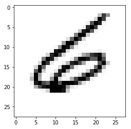

```python
# Assign filename to variable: file
file = 'mnist_kaggle_some_rows.csv'

# Load file as array: digits
digits = np.loadtxt(file, delimiter=',')

# Print datatype of digits
print(type(digits))

# Select and reshape a row
im = digits[21, 1:]
im_sq = np.reshape(im, (28, 28))

# Plot reshaped data (matplotlib.pyplot already loaded as plt)
plt.imshow(im_sq, cmap='Greys', interpolation='nearest')
plt.show()
```

### Customizing your NumPy import

```python
# Import numpy
import numpy as np

# Assign the filename: file
file = 'digits_header.txt'

# Load the data: data
data = np.loadtxt(file, delimiter='\t', skiprows=1, usecols=[0,2])

# Print data
print(data)
```

[output not shown]

### Importing different datatypes

```python
# Assign filename: file
file = 'seaslug.txt'

# Import file: data
data = np.loadtxt(file, delimiter='\t', dtype=str)

# Print the first element of data
print(data[0:5])
```

```
[['Time' 'Percent']
 ['99' '0.067']
 ['99' '0.133']
 ['99' '0.067']
 ['99' '0']]
```

```
[[ 0.     0.857]
 [ 0.     0.5  ]
 [ 0.     0.357]]
```

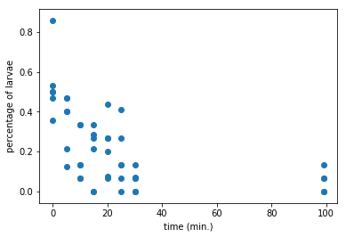

```python
# Import data as floats and skip the first row: data_float
data_float = np.loadtxt(file, delimiter='\t', dtype=float, skiprows=1)

# Print some element of data_float
print(data_float[7:10])

# Plot a scatterplot of the data
plt.scatter(data_float[:, 0], data_float[:, 1])
plt.xlabel('time (min.)')
plt.ylabel('percentage of larvae')
plt.show()
```

### Working with mixed datatypes (1)

- Here, the first argument is the filename, the second specifies the delimiter , and the third argument names tells us there is a header.
- Because the data are of different types, data is an object called a structured array.
- Because numpy arrays have to contain elements that are all the same type, the structured array solves this by being a 1D array, where each element of the array is a row of the flat file imported.

```python
data = np.genfromtxt('https://assets.datacamp.com/production/course_1607/datasets/titanic_sub.csv', delimiter=',', names=True, dtype=None)
np.shape(data)
```

```
(891,)
```

```python
data[0]
```

```
(1, 0, 3, b'male',  22., 1, 0, b'A/5 21171',  7.25, b'', b'S')
```

```python
data['Survived']
```

```
array([0, 1, 1, 1, 0, 0, 0, 0, 1, 1, 1, 1, 0, 0, 0, 1, 0, 1, 0, 1, 0, 1, 1,
       1, 0, 1, 0, 0, 1, 0, 0, 1, 1, 0, 0, 0, 1, 0, 0, 1, 0, 0, 0, 1, 1, 0,
       0, 1, 0, 0, 0, 0, 1, 1, 0, 1, 1, 0, 1, 0, 0, 1, 0, 0, 0, 1, 1, 0, 1,
       0, 0, 0, 0, 0, 1, 0, 0, 0, 1, 1, 0, 1, 1, 0, 1, 1, 0, 0, 1, 0, 0, 0,
       0, 0, 0, 0, 0, 1, 1, 0, 0, 0, 0, 0, 0, 0, 1, 1, 0, 1, 0, 0, 0, 0, 0,
       0, 0, 0, 0, 0, 0, 0, 0, 1, 0, 1, 0, 1, 1, 0, 0, 0, 0, 1, 0, 0, 1, 0,
       0, 0, 0, 1, 1, 0, 0, 0, 1, 0, 0, 0, 0, 1, 0, 0, 0, 0, 1, 0, 0, 0, 0,
       1, 0, 0, 0, 1, 1, 0, 0, 0, 0, 0, 1, 0, 0, 0, 0, 0, 0, 0, 0, 0, 0, 1,
       1, 0, 1, 1, 0, 0, 1, 0, 1, 1, 1, 1, 0, 0, 1, 0, 0, 0, 0, 0, 1, 0, 0,
       1, 1, 1, 0, 1, 0, 0, 0, 1, 1, 0, 1, 0, 1, 0, 0, 0, 1, 0, 1, 0, 0, 0,
       1, 0, 0, 1, 0, 0, 0, 1, 0, 0, 0, 1, 0, 0, 0, 0, 0, 1, 1, 0, 0, 0, 0,
       0, 0, 1, 1, 1, 1, 1, 0, 1, 0, 0, 0, 0, 0, 1, 1, 1, 0, 1, 1, 0, 1, 1,
       0, 0, 0, 1, 0, 0, 0, 1, 0, 0, 1, 0, 1, 1, 1, 1, 0, 0, 0, 0, 0, 0, 1,
       1, 1, 1, 0, 1, 0, 1, 1, 1, 0, 1, 1, 1, 0, 0, 0, 1, 1, 0, 1, 1, 0, 0,
       1, 1, 0, 1, 0, 1, 1, 1, 1, 0, 0, 0, 1, 0, 0, 1, 1, 0, 1, 1, 0, 0, 0,
```

[output cut: 24 more lines]

### Working with mixed datatypes (2)

- `np.recfromcsv()` that behaves similarly to `np.genfromtxt()`, except that its default `dtype` is `None`.

```python
# Assign the filename: file
file = 'https://assets.datacamp.com/production/course_1607/datasets/titanic_sub.csv'

# Import file using np.recfromcsv: d
d = np.recfromcsv(file)

# Print out first three entries of d
print(d[:3])
```

```
[(1, 0, 3, b'male',  22., 1, 0, b'A/5 21171',   7.25  , b'', b'S')
 (2, 1, 1, b'female',  38., 1, 0, b'PC 17599',  71.2833, b'C85', b'C')
 (3, 1, 3, b'female',  26., 0, 0, b'STON/O2. 3101282',   7.925 , b'', b'S')]
```

## Importing flat files using pandas

#### What a data scientist really needs:

- Two-dimensional labeld dsata structures
- Columns of potentially different types
- Manipulate, slice, reshape, groupby, join, merge
- perform statistics easily
- work with time series data

#### Pandas and the Dataframe

- Wes McKiney created pandas
- The documentation for the library is great
- "Python has long been great for data munging and preparation, but less so for data analysis and modeling. Pandas helpls fill this gap, enabling you to carry out your entire data anaysis workflow in Python without having to switch to a more domain specific language like R.' :)
- Python dataframe is the pythonic analog of R's data frame
- "A matrix has rows and columns, a dataframe has observations and variables" - Hadley Wickham

#### Manipulating pandas dataframes

- Exploratory data analysis
- data wrangling
- data preprocessing
- building models
- visualization
- its now standard and best practice to use pandas to import and work with dataframes

#### Importing using pandas

```python
import pandas as pd
filename = 'https://assets.datacamp.com/production/course_1607/datasets/titanic_sub.csv'
data = pd.read_csv(filename)
data.head()
```

|  | PassengerId | Survived | Pclass | Sex | Age | SibSp | Parch | Ticket | Fare | Cabin | Embarked |
| --- | --- | --- | --- | --- | --- | --- | --- | --- | --- | --- | --- |
| 0 | 1 | 0 | 3 | male | 22.0 | 1 | 0 | A/5 21171 | 7.2500 | NaN | S |
| 1 | 2 | 1 | 1 | female | 38.0 | 1 | 0 | PC 17599 | 71.2833 | C85 | C |
| 2 | 3 | 1 | 3 | female | 26.0 | 0 | 0 | STON/O2. 3101282 | 7.9250 | NaN | S |
| 3 | 4 | 1 | 1 | female | 35.0 | 1 | 0 | 113803 | 53.1000 | C123 | S |
| 4 | 5 | 0 | 3 | male | 35.0 | 0 | 0 | 373450 | 8.0500 | NaN | S |

```python
# convert the dataframe to a numpy array
data_array = data.values
data_array
```

```
array([[1, 0, 3, ..., 7.25, nan, 'S'],
       [2, 1, 1, ..., 71.2833, 'C85', 'C'],
       [3, 1, 3, ..., 7.925, nan, 'S'],
       ...,
       [889, 0, 3, ..., 23.45, nan, 'S'],
       [890, 1, 1, ..., 30.0, 'C148', 'C'],
       [891, 0, 3, ..., 7.75, nan, 'Q']], dtype=object)
```

### Using pandas to import flat files as DataFrames (1)

```python
# Assign the filename: file
file = 'https://assets.datacamp.com/production/course_1607/datasets/titanic_sub.csv'

# Read the file into a DataFrame: df
df = pd.read_csv(file)

# View the head of the DataFrame
print(df.head())
```

```
   PassengerId  Survived  Pclass     Sex   Age  SibSp  Parch  \
0            1         0       3    male  22.0      1      0
1            2         1       1  female  38.0      1      0
2            3         1       3  female  26.0      0      0
3            4         1       1  female  35.0      1      0
4            5         0       3    male  35.0      0      0

             Ticket     Fare Cabin Embarked
0         A/5 21171   7.2500   NaN        S
1          PC 17599  71.2833   C85        C
2  STON/O2. 3101282   7.9250   NaN        S
3            113803  53.1000  C123        S
4            373450   8.0500   NaN        S
```

### Using pandas to import flat files as DataFrames (2)

```python
# Assign the filename: file
file = 'https://assets.datacamp.com/production/course_1607/datasets/mnist_kaggle_some_rows.csv'

# Read the first 5 rows of the file into a DataFrame: data
data = pd.read_csv(file, header = None, nrows = 5)

data
```

|  | 0 | 1 | 2 | 3 | 4 | 5 | 6 | 7 | 8 | 9 | ... | 775 | 776 | 777 | 778 | 779 | 780 | 781 | 782 | 783 | 784 |
| --- | --- | --- | --- | --- | --- | --- | --- | --- | --- | --- | --- | --- | --- | --- | --- | --- | --- | --- | --- | --- | --- |
| 0 | 1.0 | 0.0 | 0.0 | 0.0 | 0.0 | 0.0 | 0.0 | 0.0 | 0.0 | 0.0 | ... | 0.0 | 0.0 | 0.0 | 0.0 | 0.0 | 0.0 | 0.0 | 0.0 | 0.0 | 0.0 |
| 1 | 0.0 | 0.0 | 0.0 | 0.0 | 0.0 | 0.0 | 0.0 | 0.0 | 0.0 | 0.0 | ... | 0.0 | 0.0 | 0.0 | 0.0 | 0.0 | 0.0 | 0.0 | 0.0 | 0.0 | 0.0 |
| 2 | 1.0 | 0.0 | 0.0 | 0.0 | 0.0 | 0.0 | 0.0 | 0.0 | 0.0 | 0.0 | ... | 0.0 | 0.0 | 0.0 | 0.0 | 0.0 | 0.0 | 0.0 | 0.0 | 0.0 | 0.0 |
| 3 | 4.0 | 0.0 | 0.0 | 0.0 | 0.0 | 0.0 | 0.0 | 0.0 | 0.0 | 0.0 | ... | 0.0 | 0.0 | 0.0 | 0.0 | 0.0 | 0.0 | 0.0 | 0.0 | 0.0 | 0.0 |
| 4 | 0.0 | 0.0 | 0.0 | 0.0 | 0.0 | 0.0 | 0.0 | 0.0 | 0.0 | 0.0 | ... | 0.0 | 0.0 | 0.0 | 0.0 | 0.0 | 0.0 | 0.0 | 0.0 | 0.0 | 0.0 |

5 rows × 785 columns

```python
# Build a numpy array from the DataFrame: data_array
data_array = data.values

# Print the datatype of data_array to the shell
print(type(data_array))
```

```
<class 'numpy.ndarray'>
```

### Customizing your pandas import

```python
# Assign filename: file
file = 'titanic_corrupt.txt'

# Import file: data
data = pd.read_csv(file, sep=',', comment='#', na_values='Nothing')

# Print the head of the DataFrame
data[0:5]
```

|  | PassengerId | Survived | Pclass | Sex | Age | SibSp | Parch | Ticket | Fare | Cabin | Embarked |
| --- | --- | --- | --- | --- | --- | --- | --- | --- | --- | --- | --- |
| 0 | 1 | 0 | NaN | male | 22.0 | 1 | 0 | A/5 21171 | 7.2500 | NaN | S |
| 1 | 2 | 1 | NaN | female | 38.0 | 1 | 0 | PC 17599 | 71.2833 | C85 | C |
| 2 | 3 | 1 | 3.0 | female | 26.0 | 0 | 0 | STON/O2. 3101282 | 7.9250 | NaN | S |
| 3 | 4 | 1 | 1.0 | female | 35.0 | 1 | 0 | 113803 | 53.1000 | C123 | S |
| 4 | 5 | 0 | 3.0 | male | 35.0 | 0 | 0 | 373450 | 8.0500 | NaN | S |

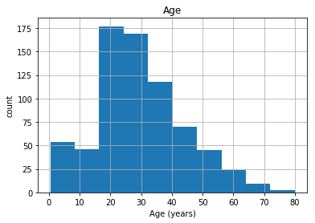

```python
# Plot 'Age' variable in a histogram
pd.DataFrame.hist(data[['Age']])
plt.xlabel('Age (years)')
plt.ylabel('count')
plt.show()
```

### Final thoughts on data import

- Definitely keep your eyes on feather. A fast language agnostic data frame file format by hadley and wes.

# Importing data from other files

## Introduction to other file types

#### Some other file types we will practice with here

- Excel
- MATLAB
- SAS
- Stata
- HDF5
- Pickled
  - file type native to python
  - motivation: there are many data types for which it isn't obvious how to store them
  - pickled files are serialized
  - Serialize = convert object to bytestream

#### Pickle example

```python
# First I need to make a pickle file
import pickle

fruit = ['apple','orange','lemon','lime']

# w is for write and b is for binary I guess
pickle.dump(fruit, open('pickled_fruit.pkl', "wb"))
```

```python
# Now I can open it
# r means read, b means binary
with open('pickled_fruit.pkl', 'rb') as file:
    data = pickle.load(file)

print(data)
```

```
['apple', 'orange', 'lemon', 'lime']
```

#### Importing Excel spreadsheets

- They don't offer this data file on the class site
  - but I remember using this file for the importing data in R class. : )

#### Example - Save excel file to disk then open

```python
urllib.request.urlretrieve(
    "http://docs.google.com/spreadsheet/pub?key=pyj6tScZqmEfH89V6UQhpZA&output=xlsx",
    filename="urban_pop_orig.xlsx")
```

```
('urban_pop_orig.xlsx', <http.client.HTTPMessage at 0x1089aa1d0>)
```

- Note I needed to `conda instal xlrd` for the `pd.ExcelFile()` function to work

```python
data = pd.ExcelFile('urban_pop_orig.xlsx')
print(data.sheet_names)
```

```
['Data', 'About', 'Footnotes', 'Settings', 'Download', 'v']
```

#### Example - Load excel file from web

```python
file_url = urllib.request.urlopen("http://docs.google.com/spreadsheet/pub?key=pyj6tScZqmEfH89V6UQhpZA&output=xlsx")
data = pd.ExcelFile(file_url)
print(data.sheet_names)
```

```
['Data', 'About', 'Footnotes', 'Settings', 'Download', 'v']
```

Now we can grab the data in a worksheet with the worksheet name or the index...

```python
df1 = data.parse('Data')
df1.head()
```

|  | Urban population | 1960 | 1961 | 1962 | 1963 | 1964 | 1965 | 1966 | 1967 | 1968 | ... | 2002 | 2003 | 2004 | 2005 | 2006 | 2007 | 2008 | 2009 | 2010 | 2011 |
| --- | --- | --- | --- | --- | --- | --- | --- | --- | --- | --- | --- | --- | --- | --- | --- | --- | --- | --- | --- | --- | --- |
| 0 | Abkhazia | NaN | NaN | NaN | NaN | NaN | NaN | NaN | NaN | NaN | ... | NaN | NaN | NaN | NaN | NaN | NaN | NaN | NaN | NaN | NaN |
| 1 | Afghanistan | 769308.0 | 8.149230e+05 | 8.585217e+05 | 9.039139e+05 | 9.512259e+05 | 1.000582e+06 | 1.058743e+06 | 1.119067e+06 | 1.182159e+06 | ... | 5.795940e+06 | 6.036100e+06 | 6.285281e+06 | 6.543804e+06 | 6.812538e+06 | 7.091245e+06 | 7.380272e+06 | 7.679982e+06 | 7.990746e+06 | 8.316976e+06 |
| 2 | Akrotiri and Dhekelia | NaN | NaN | NaN | NaN | NaN | NaN | NaN | NaN | NaN | ... | NaN | NaN | NaN | NaN | NaN | NaN | NaN | NaN | NaN | NaN |
| 3 | Albania | 494443.0 | 5.118028e+05 | 5.294389e+05 | 5.473767e+05 | 5.655718e+05 | 5.839829e+05 | 6.025122e+05 | 6.211798e+05 | 6.399645e+05 | ... | 1.352278e+06 | 1.391143e+06 | 1.430918e+06 | 1.470488e+06 | 1.512255e+06 | 1.553491e+06 | 1.594351e+06 | 1.635262e+06 | 1.676545e+06 | 1.716842e+06 |
| 4 | Algeria | 3293999.0 | 3.515148e+06 | 3.739963e+06 | 3.973289e+06 | 4.220987e+06 | 4.488176e+06 | 4.649105e+06 | 4.826104e+06 | 5.017299e+06 | ... | 1.985484e+07 | 2.052936e+07 | 2.122220e+07 | 2.193298e+07 | 2.262505e+07 | 2.333554e+07 | 2.406175e+07 | 2.479959e+07 | 2.554562e+07 | 2.621697e+07 |

5 rows × 53 columns

```python
df2 = data.parse(0)
df2.head()
```

|  | Urban population | 1960 | 1961 | 1962 | 1963 | 1964 | 1965 | 1966 | 1967 | 1968 | ... | 2002 | 2003 | 2004 | 2005 | 2006 | 2007 | 2008 | 2009 | 2010 | 2011 |
| --- | --- | --- | --- | --- | --- | --- | --- | --- | --- | --- | --- | --- | --- | --- | --- | --- | --- | --- | --- | --- | --- |
| 0 | Abkhazia | NaN | NaN | NaN | NaN | NaN | NaN | NaN | NaN | NaN | ... | NaN | NaN | NaN | NaN | NaN | NaN | NaN | NaN | NaN | NaN |
| 1 | Afghanistan | 769308.0 | 8.149230e+05 | 8.585217e+05 | 9.039139e+05 | 9.512259e+05 | 1.000582e+06 | 1.058743e+06 | 1.119067e+06 | 1.182159e+06 | ... | 5.795940e+06 | 6.036100e+06 | 6.285281e+06 | 6.543804e+06 | 6.812538e+06 | 7.091245e+06 | 7.380272e+06 | 7.679982e+06 | 7.990746e+06 | 8.316976e+06 |
| 2 | Akrotiri and Dhekelia | NaN | NaN | NaN | NaN | NaN | NaN | NaN | NaN | NaN | ... | NaN | NaN | NaN | NaN | NaN | NaN | NaN | NaN | NaN | NaN |
| 3 | Albania | 494443.0 | 5.118028e+05 | 5.294389e+05 | 5.473767e+05 | 5.655718e+05 | 5.839829e+05 | 6.025122e+05 | 6.211798e+05 | 6.399645e+05 | ... | 1.352278e+06 | 1.391143e+06 | 1.430918e+06 | 1.470488e+06 | 1.512255e+06 | 1.553491e+06 | 1.594351e+06 | 1.635262e+06 | 1.676545e+06 | 1.716842e+06 |
| 4 | Algeria | 3293999.0 | 3.515148e+06 | 3.739963e+06 | 3.973289e+06 | 4.220987e+06 | 4.488176e+06 | 4.649105e+06 | 4.826104e+06 | 5.017299e+06 | ... | 1.985484e+07 | 2.052936e+07 | 2.122220e+07 | 2.193298e+07 | 2.262505e+07 | 2.333554e+07 | 2.406175e+07 | 2.479959e+07 | 2.554562e+07 | 2.621697e+07 |

5 rows × 53 columns

### Not so flat any more

```python
import os
wd = os.getcwd()
os.listdir(wd)
```

```
['.ipynb_checkpoints',
 'assets.datacamp.com',
 'custom.css',
 'huck_finn.txt',
 'importing_data_in_python_part_1.html',
 'importing_data_in_python_part_1.ipynb',
 'mnist_kaggle_some_rows.csv',
 'pickled_fruit.pkl',
 'seaslug.txt',
 'titanic_corrupt.txt',
 'urban_pop_orig.xlsx']
```

### Loading a pickled file

```python
# Import pickle package
import pickle

# Open pickle file and load data: d
with open('pickled_fruit.pkl', 'rb') as file:
    d = pickle.load(file)

# Print d
print(d)

# Print datatype of d
print(type(d))
```

```
['apple', 'orange', 'lemon', 'lime']
<class 'list'>
```

### Listing sheets in Excel files

```python
# Assign spreadsheet filename: file
file = "battledeath.xlsx"

# Load spreadsheet: xl
xl = pd.ExcelFile(file)

# Print sheet names
print(xl.sheet_names)
```

```
['2002', '2004']
```

### Importing sheets from Excel files

```python
# Load a sheet into a DataFrame by name: df1
df1 = xl.parse('2004')

# Print the head of the DataFrame df1
print(df1.head())

# Load a sheet into a DataFrame by index: df2
df2 = xl.parse(0)

# Print the head of the DataFrame df2
print(df2.head())
```

```
  War(country)      2004
0  Afghanistan  9.451028
1      Albania  0.130354
2      Algeria  3.407277
3      Andorra  0.000000
4       Angola  2.597931
  War, age-adjusted mortality due to       2002
0                        Afghanistan  36.083990
1                            Albania   0.128908
2                            Algeria  18.314120
3                            Andorra   0.000000
4                             Angola  18.964560
```

### Customizing your spreadsheet import

```python
# Parse the first sheet and rename the columns: df1
df1 = xl.parse(0, skiprows=[0], names=['Country','AAM due to War (2002)'])

# Print the head of the DataFrame df1
print(df1.head())

# Parse the first column of the second sheet and rename the column: df2
df2 = xl.parse(1, parse_cols=[0], skiprows=[0], names=['Country'])

# Print the head of the DataFrame df2
print(df2.head())
```

```
               Country  AAM due to War (2002)
0              Albania               0.128908
1              Algeria              18.314120
2              Andorra               0.000000
3               Angola              18.964560
4  Antigua and Barbuda               0.000000
               Country
0              Albania
1              Algeria
2              Andorra
3               Angola
4  Antigua and Barbuda
```

## Importing SAS/Stata files using pandas

- SAS: Statistical Analysis System
  - business analytics and biostatistics
- Stata: 'Statistics' + 'data'
  - acedemic social sciences research

### Importing SAS files

```python
# import pandas as pd
from sas7bdat import SAS7BDAT

with SAS7BDAT('sales.sas7bdat') as file:
    df_sas = file.to_data_frame()

df_sas.head()
```

|  | YEAR | P | S |
| --- | --- | --- | --- |
| 0 | 1950.0 | 12.9 | 181.899994 |
| 1 | 1951.0 | 11.9 | 245.000000 |
| 2 | 1952.0 | 10.7 | 250.199997 |
| 3 | 1953.0 | 11.3 | 265.899994 |
| 4 | 1954.0 | 11.2 | 248.500000 |

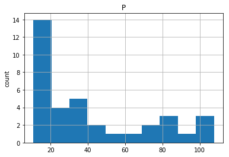

```python
# Plot histogram of DataFrame features (pandas and pyplot already imported)
pd.DataFrame.hist(df_sas[['P']])
plt.ylabel('count')
plt.show()
```

### Importing Stata files

- This is easy to do directly with pandas and does not require a content manager

```python
# Import pandas
import pandas as pd

# Load Stata file into a pandas DataFrame: df
df = pd.read_stata('disarea.dta')

# Print the head of the DataFrame df
df.head()
```

|  | wbcode | country | disa1 | disa2 | disa3 | disa4 | disa5 | disa6 | disa7 | disa8 | ... | disa16 | disa17 | disa18 | disa19 | disa20 | disa21 | disa22 | disa23 | disa24 | disa25 |
| --- | --- | --- | --- | --- | --- | --- | --- | --- | --- | --- | --- | --- | --- | --- | --- | --- | --- | --- | --- | --- | --- |
| 0 | AFG | Afghanistan | 0.00 | 0.00 | 0.76 | 0.73 | 0.0 | 0.00 | 0.00 | 0.0 | ... | 0.0 | 0.0 | 0.0 | 0.00 | 0.00 | 0.0 | 0.00 | 0.02 | 0.00 | 0.00 |
| 1 | AGO | Angola | 0.32 | 0.02 | 0.56 | 0.00 | 0.0 | 0.00 | 0.56 | 0.0 | ... | 0.0 | 0.4 | 0.0 | 0.61 | 0.00 | 0.0 | 0.99 | 0.98 | 0.61 | 0.00 |
| 2 | ALB | Albania | 0.00 | 0.00 | 0.02 | 0.00 | 0.0 | 0.00 | 0.00 | 0.0 | ... | 0.0 | 0.0 | 0.0 | 0.00 | 0.00 | 0.0 | 0.00 | 0.00 | 0.00 | 0.16 |
| 3 | ARE | United Arab Emirates | 0.00 | 0.00 | 0.00 | 0.00 | 0.0 | 0.00 | 0.00 | 0.0 | ... | 0.0 | 0.0 | 0.0 | 0.00 | 0.00 | 0.0 | 0.00 | 0.00 | 0.00 | 0.00 |
| 4 | ARG | Argentina | 0.00 | 0.24 | 0.24 | 0.00 | 0.0 | 0.23 | 0.00 | 0.0 | ... | 0.0 | 0.0 | 0.0 | 0.00 | 0.05 | 0.0 | 0.00 | 0.01 | 0.00 | 0.11 |

5 rows × 27 columns

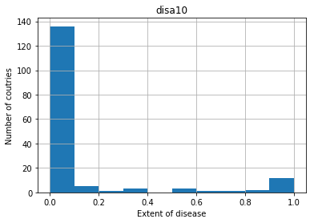

```python
# Plot histogram of one column of the DataFrame
pd.DataFrame.hist(df[['disa10']])
plt.xlabel('Extent of disease')
plt.ylabel('Number of coutries')
plt.show()
```

## Importing HDF5 files

#### HFF5 files

- Hierarchical Data Format version 5
- Standard for storing large quantities of numerical data
- Datasets can now be hundreds of gigabytes or terabytes
- HDF5 can scale to exabytes

#### Imprting HDF5 files

```python
import h5py

filename = 'L-L1_LOSC_4_V1-1126259446-32.hdf5'

data = h5py.File(filename, 'r')

print(type(data))
```

```
<class 'h5py._hl.files.File'>
```

#### The structure of HDF5 files

```python
for key in data.keys():
    print(key)
```

```
meta
quality
strain
```

```python
print(type(data['meta']))
```

```
<class 'h5py._hl.group.Group'>
```

```python
for key in data['meta'].keys():
    print(key)
```

```
Description
DescriptionURL
Detector
Duration
GPSstart
Observatory
Type
UTCstart
```

```python
print(data['meta']['Description'].value,
      data['meta']['Detector'].value)
```

```
b'Strain data time series from LIGO' b'L1'
```

### Using h5py to import HDF5 files

```python
# Import packages
# import numpy as np
# import h5py

# Assign filename: file
file = 'L-L1_LOSC_4_V1-1126259446-32.hdf5'

# Load file: data
data = h5py.File(file, 'r')

# Print the datatype of the loaded file
print(type(data))

# Print the keys of the file
for key in data.keys():
    print(key)
```

```
<class 'h5py._hl.files.File'>
meta
quality
strain
```

### Extracting data from your HDF5 file

```
Strain
```

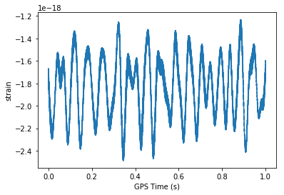

```python
# Get the HDF5 group: group
group = data['strain']

# Check out keys of group
for key in group.keys():
    print(key)

# Set variable equal to time series data: strain
strain = data['strain']['Strain'].value

# Set number of time points to sample: num_samples
num_samples = 10000

# Set time vector
time = np.arange(0, 1, 1/num_samples)

# Plot data
plt.plot(time, strain[:num_samples])
plt.xlabel('GPS Time (s)')
plt.ylabel('strain')
plt.show()
```

## Importing MATLAB files

SciPy can handle it easily

- `scipy.io.loadmat()` - read `.mat` files
- `scipy.io.savemat()` - write `.mat` files

### Loading .mat files

```python
# Import package
import scipy.io

# Load MATLAB file: mat
filename = 'data/ja_data2.mat'

mat = scipy.io.loadmat(filename)

# Print the datatype type of mat
print(type(mat))
```

```
<class 'dict'>
```

- keys = MATLAB variable names
- values = objects assigned to variables

### The structure of .mat in Python

```python
# Print the keys of the MATLAB dictionary
print(mat.keys())
```

```
dict_keys(['__header__', '__version__', '__globals__', 'rfpCyt', 'rfpNuc', 'cfpNuc', 'cfpCyt', 'yfpNuc', 'yfpCyt', 'CYratioCyt'])
```

```python
# Print the type of the value corresponding to the key 'CYratioCyt'
print(type(mat['CYratioCyt']))
```

```
<class 'numpy.ndarray'>
```

```python
# Print the shape of the value corresponding to the key 'CYratioCyt'
print(np.shape(mat['CYratioCyt']))
```

```
(200, 137)
```

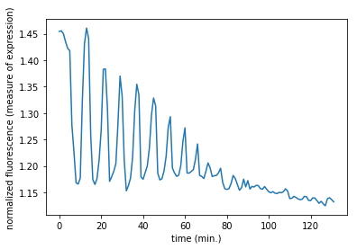

```python
# Subset the array and plot it
data = mat['CYratioCyt'][25, 5:]
fig = plt.figure()
plt.plot(data)
plt.xlabel('time (min.)')
plt.ylabel('normalized fluorescence (measure of expression)')
plt.show()
```

# Working with relational databases in Python

## Introduction to relational databases

### Pop quiz: The relational model

- Each row or record in a table represents an instance of an entity type.
- Each column in a table represents an attribute or feature of an instance.
- Every table contains a primary key column, which has a unique entry for each row.
- There are relations between tables.

## Creating a database engine in Python

#### Creating a database engine

- SQLite database
  - Fast and simple
- SQLAlchemy
  - Works with many relational database management systems

### Creating a database engine

- Here, 'sqlite:///Chinook.sqlite' is called the connection string to the SQLite database Chinook.sqlite.
- A little bit of background on the Chinook database:
  - the Chinook database contains information about a semi-fictional digital media store in which media data is real and customer, employee and sales data has been manually created.

```python
from sqlalchemy import create_engine

engine = create_engine('sqlite:///data/Chinook.sqlite')
```

### What are the tables in the database?

```python
# get table names
table_names = engine.table_names()

print(table_names)
```

```
['Album', 'Artist', 'Customer', 'Employee', 'Genre', 'Invoice', 'InvoiceLine', 'MediaType', 'Playlist', 'PlaylistTrack', 'Track']
```

## Querying relational databases in Python

#### Workflow of SQL querying

- Import packages and functions
- Create the database engine
- Connect to the engine
- Query the database
- Save query results to a DataFrame
- Close the connection

#### Your first SQL query

- We need to assign the column names after fetching the data or they will just be index numbers

```python
# from sqlalchemy import create_engine
# import pandas as pd
engine = create_engine('sqlite:///data/Chinook.sqlite')
con = engine.connect()

rs = con.execute("SELECT * FROM Album")
df = pd.DataFrame(rs.fetchall())
df.columns = rs.keys()

con.close()

print(df.shape)
df.head()
```

```
(347, 3)
```

|  | AlbumId | Title | ArtistId |
| --- | --- | --- | --- |
| 0 | 1 | For Those About To Rock We Salute You | 1 |
| 1 | 2 | Balls to the Wall | 2 |
| 2 | 3 | Restless and Wild | 2 |
| 3 | 4 | Let There Be Rock | 1 |
| 4 | 5 | Big Ones | 3 |

#### Using the context manager

- so you don't need to remember to close the connection
- Here, we use the column names instead of * in the sql query
- We also just select 5 rows with `fetchmany()` rather than `fetchall()`

```python
engine = create_engine('sqlite:///data/Chinook.sqlite')

with engine.connect() as con:
    rs = con.execute("SELECT ArtistId, Name FROM Artist")
    df = pd.DataFrame(rs.fetchmany(size=5))
    df.columns = rs.keys()

print(df.shape)
df.head()
```

```
(5, 2)
```

|  | ArtistId | Name |
| --- | --- | --- |
| 0 | 1 | AC/DC |
| 1 | 2 | Accept |
| 2 | 3 | Aerosmith |
| 3 | 4 | Alanis Morissette |
| 4 | 5 | Alice In Chains |

### The Hello World of SQL Queries!

```python
# Import packages
# from sqlalchemy import create_engine
# import pandas as pd

# Create engine: engine
engine = create_engine('sqlite:///data/Chinook.sqlite')

# Open engine connection: con
con = engine.connect()

# Perform query: rs
rs = con.execute("SELECT * from Album")

# Save results of the query to DataFrame: df
df = pd.DataFrame(rs.fetchall())

# Close connection
con.close()

# Print head of DataFrame df
print(df.head())
```

```
   0                                      1  2
0  1  For Those About To Rock We Salute You  1
1  2                      Balls to the Wall  2
2  3                      Restless and Wild  2
3  4                      Let There Be Rock  1
4  5                               Big Ones  3
```

### Customizing the Hello World of SQL Queries

```python
# Open engine in context manager
# Perform query and save results to DataFrame: df
with engine.connect() as con:
    rs = con.execute("SELECT LastName, Title FROM Employee")
    df = pd.DataFrame(rs.fetchmany(size=3))
    df.columns = rs.keys()

# Print the length of the DataFrame df
print(len(df))

# Print the head of the DataFrame df
print(df.head())
```

```
3
  LastName                Title
0    Adams      General Manager
1  Edwards        Sales Manager
2  Peacock  Sales Support Agent
```

### Filtering your database records using SQL's WHERE

```python
# Create engine: engine
engine = create_engine('sqlite:///data/Chinook.sqlite')

# Open engine in context manager
# Perform query and save results to DataFrame: df
with engine.connect() as con:
    rs = con.execute("select * from Employee where EmployeeId >= 6")
    df = pd.DataFrame(rs.fetchall())
    df.columns = rs.keys()

# Print the head of the DataFrame df
print(df.head())
```

```
   EmployeeId  LastName FirstName       Title  ReportsTo            BirthDate  \
0           6  Mitchell   Michael  IT Manager          1  1973-07-01 00:00:00
1           7      King    Robert    IT Staff          6  1970-05-29 00:00:00
2           8  Callahan     Laura    IT Staff          6  1968-01-09 00:00:00

              HireDate                      Address        City State Country  \
0  2003-10-17 00:00:00         5827 Bowness Road NW     Calgary    AB  Canada
1  2004-01-02 00:00:00  590 Columbia Boulevard West  Lethbridge    AB  Canada
2  2004-03-04 00:00:00                  923 7 ST NW  Lethbridge    AB  Canada

  PostalCode              Phone                Fax                    Email
0    T3B 0C5  +1 (403) 246-9887  +1 (403) 246-9899  michael@chinookcorp.com
1    T1K 5N8  +1 (403) 456-9986  +1 (403) 456-8485   robert@chinookcorp.com
2    T1H 1Y8  +1 (403) 467-3351  +1 (403) 467-8772    laura@chinookcorp.com
```

### Ordering your SQL records with ORDER BY

```python
# Open engine in context manager
with engine.connect() as con:
    rs = con.execute("select * from Employee order by BirthDate")
    df = pd.DataFrame(rs.fetchall())

    # Set the DataFrame's column names
    df.columns = rs.keys()

# Print head of DataFrame
print(df.head())
```

```
   EmployeeId  LastName FirstName                Title  ReportsTo  \
0           4      Park  Margaret  Sales Support Agent        2.0
1           2   Edwards     Nancy        Sales Manager        1.0
2           1     Adams    Andrew      General Manager        NaN
3           5   Johnson     Steve  Sales Support Agent        2.0
4           8  Callahan     Laura             IT Staff        6.0

             BirthDate             HireDate              Address        City  \
0  1947-09-19 00:00:00  2003-05-03 00:00:00     683 10 Street SW     Calgary
1  1958-12-08 00:00:00  2002-05-01 00:00:00         825 8 Ave SW     Calgary
2  1962-02-18 00:00:00  2002-08-14 00:00:00  11120 Jasper Ave NW    Edmonton
3  1965-03-03 00:00:00  2003-10-17 00:00:00         7727B 41 Ave     Calgary
4  1968-01-09 00:00:00  2004-03-04 00:00:00          923 7 ST NW  Lethbridge

  State Country PostalCode              Phone                Fax  \
0    AB  Canada    T2P 5G3  +1 (403) 263-4423  +1 (403) 263-4289
1    AB  Canada    T2P 2T3  +1 (403) 262-3443  +1 (403) 262-3322
2    AB  Canada    T5K 2N1  +1 (780) 428-9482  +1 (780) 428-3457
3    AB  Canada    T3B 1Y7   1 (780) 836-9987   1 (780) 836-9543
4    AB  Canada    T1H 1Y8  +1 (403) 467-3351  +1 (403) 467-8772

                      Email
0  margaret@chinookcorp.com
1     nancy@chinookcorp.com
2    andrew@chinookcorp.com
3     steve@chinookcorp.com
4     laura@chinookcorp.com
```

## Querying relational databases directly with pandas

- Damn so yeah, all that connection stuff we just learned...
- Well, once again you can just do it with one line of pandas (like most stuff we have learned here)

```python
df = pd.read_sql_query("SELECT * FROM Album", engine)
df.head()
```

|  | AlbumId | Title | ArtistId |
| --- | --- | --- | --- |
| 0 | 1 | For Those About To Rock We Salute You | 1 |
| 1 | 2 | Balls to the Wall | 2 |
| 2 | 3 | Restless and Wild | 2 |
| 3 | 4 | Let There Be Rock | 1 |
| 4 | 5 | Big Ones | 3 |

### Pandas and The Hello World of SQL Queries!

```python
# Execute query and store records in DataFrame: df
df = pd.read_sql_query("select * from Album", engine)

# Print head of DataFrame
print(df.head())
```

```
   AlbumId                                  Title  ArtistId
0        1  For Those About To Rock We Salute You         1
1        2                      Balls to the Wall         2
2        3                      Restless and Wild         2
3        4                      Let There Be Rock         1
4        5                               Big Ones         3
```

```python
# Open engine in context manager
# Perform query and save results to DataFrame: df1
with engine.connect() as con:
    rs = con.execute("SELECT * FROM Album")
    df1 = pd.DataFrame(rs.fetchall())
    df1.columns = rs.keys()

# Confirm that both methods yield the same result: does df = df1 ?
print(df.equals(df1))
```

```
True
```

### Pandas for more complex querying

```python
# Execute query and store records in DataFrame: df
df = pd.read_sql_query("select * from Employee where EmployeeId >= 6 order by BirthDate", engine)

# Print head of DataFrame
print(df.head())
```

```
   EmployeeId  LastName FirstName       Title  ReportsTo            BirthDate  \
0           8  Callahan     Laura    IT Staff          6  1968-01-09 00:00:00
1           7      King    Robert    IT Staff          6  1970-05-29 00:00:00
2           6  Mitchell   Michael  IT Manager          1  1973-07-01 00:00:00

              HireDate                      Address        City State Country  \
0  2004-03-04 00:00:00                  923 7 ST NW  Lethbridge    AB  Canada
1  2004-01-02 00:00:00  590 Columbia Boulevard West  Lethbridge    AB  Canada
2  2003-10-17 00:00:00         5827 Bowness Road NW     Calgary    AB  Canada

  PostalCode              Phone                Fax                    Email
0    T1H 1Y8  +1 (403) 467-3351  +1 (403) 467-8772    laura@chinookcorp.com
1    T1K 5N8  +1 (403) 456-9986  +1 (403) 456-8485   robert@chinookcorp.com
2    T3B 0C5  +1 (403) 246-9887  +1 (403) 246-9899  michael@chinookcorp.com
```

## Advanced Querying: exploiting table relationships

### The power of SQL lies in relationships between tables: INNER JOIN

```python
# Open engine in context manager
# Perform query and save results to DataFrame: df
with engine.connect() as con:
    rs = con.execute(
        "select Album.Title, Artist.Name \
        from Album \
        inner join Artist \
          on Album.ArtistID = Artist.ArtistID")
    df = pd.DataFrame(rs.fetchall())
    df.columns = rs.keys()

# Print head of DataFrame df
print(df.head())
```

```
                                   Title       Name
0  For Those About To Rock We Salute You      AC/DC
1                      Balls to the Wall     Accept
2                      Restless and Wild     Accept
3                      Let There Be Rock      AC/DC
4                               Big Ones  Aerosmith
```

### Filtering your INNER JOIN

```python
# Execute query and store records in DataFrame: df
df = pd.read_sql_query(
    "select * \
    from PlaylistTrack \
    inner join Track \
     on PlaylistTrack.TrackId = Track.TrackId \
    where Milliseconds < 250000",
    engine)

# Print head of DataFrame
print(df.head())
```

```
   PlaylistId  TrackId  TrackId              Name  AlbumId  MediaTypeId  \
0           1     3390     3390  One and the Same      271            2
1           1     3392     3392     Until We Fall      271            2
2           1     3393     3393     Original Fire      271            2
3           1     3394     3394       Broken City      271            2
4           1     3395     3395          Somedays      271            2

   GenreId Composer  Milliseconds    Bytes  UnitPrice
0       23     None        217732  3559040       0.99
1       23     None        230758  3766605       0.99
2       23     None        218916  3577821       0.99
3       23     None        228366  3728955       0.99
4       23     None        213831  3497176       0.99
```

## Final Thoughts

#### Next Course

- Scrape data from the web
- Interact with APIs (like twitter)